# 955 PhysLim_exercises

Robert Ladwig, Hilary Dugan

9/16/2019

## 955 Lake Physics

You are given vertical water temperature profiles (wtemp.txt) that were measured on three days in the summer of 2004 at Lake Mendota’s deepest site. Additionally you have idealized hypsographic data (hypso.txt). Lake Mendota’s volume is approx. 479823720 cubic metres. All water temperatures are in degree Celsius, all depths in meters, and all areas in squared metres.

## Load the data into R

```r
# Set your working directory to your file location. For example:
# setwd('/Users/robertladwig/Dropbox/955_seminar')

# Read in the two data files
wtemp <- read.delim('wtemp.txt', sep = '\t')
head(wtemp)
```

```
##   Depth X2004.06.21 X2004.07.06 X2004.08.03
## 1     0        20.6        21.9        24.3
## 2     1        20.6        21.8        24.0
## 3     2        20.6        21.7        24.0
## 4     3        20.6        21.5        23.8
## 5     4        20.6        21.4        23.5
## 6     5        20.6        21.2        23.5
```

```r
hypso <- read.delim('hypso.txt', sep = '\t')
head(hypso)
```

```
##   Depth     Area
## 1     0 39581170
## 2     1 37997520
## 3     2 36413868
## 4     3 34830210
## 5     4 33246555
## 6     5 31662905
```

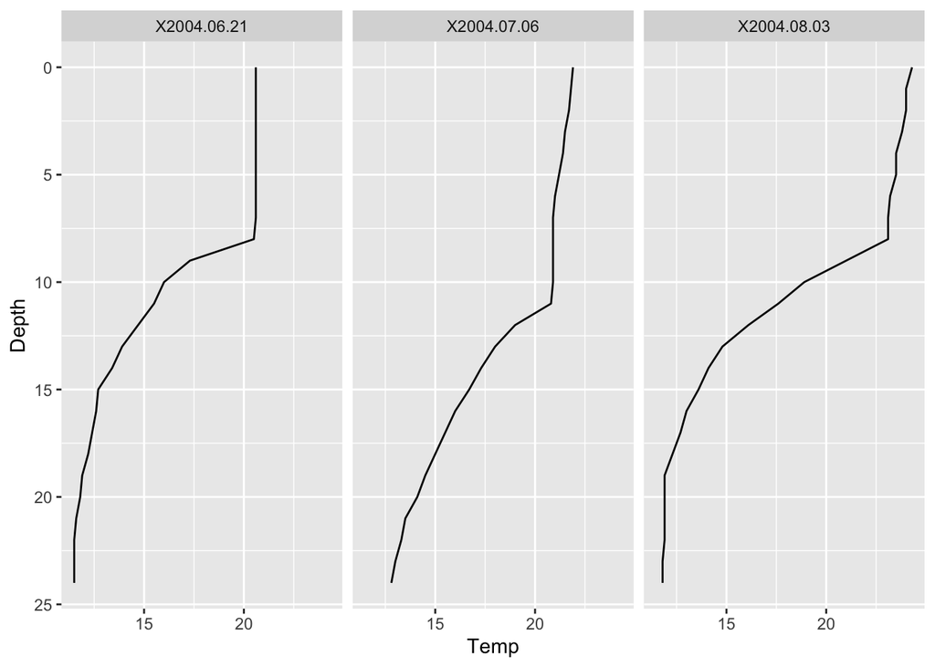

```r
V <- 479823720 #Volume of Lake Mendota

# Might be easier to work with a 'long' dataframe rather than 'wide'
wtempLong = wtemp %>% gather(Date,Temp,-Depth)

# How to plot temperature profiles
ggplot(wtempLong) + geom_path(aes(x = Temp, y = Depth)) +
  scale_y_reverse() +
  facet_grid(cols = vars(Date))
```

## Questions:

1. Convert the water temperatures into vertical water density profiles (in kg per m3), use the given fifth-order polynomial to approximate the densities:
2. Calculate the vertical buoyancy frequencies for every depth (go from top to bottom, and compare adjacent layers) and find the depth of the maximum buoyancy frequency. What do these depths implicate for the thermocline depths? Advice: Use 998.2 kg/m3 as reference water density.
3. What differences in the horizontal velocity would be needed to cause turbulence for the specific-depths of the maximum buoyancy frequencies? Approach this question by using the Richardson number under turbulent conditions.
4. How much energy is needed on each of these days to mix the entire water body? Calculate the Schmidt stability of the total water column for each day. Simplify the problem by substituting the integral with a product.

## (1) Convert to water densities

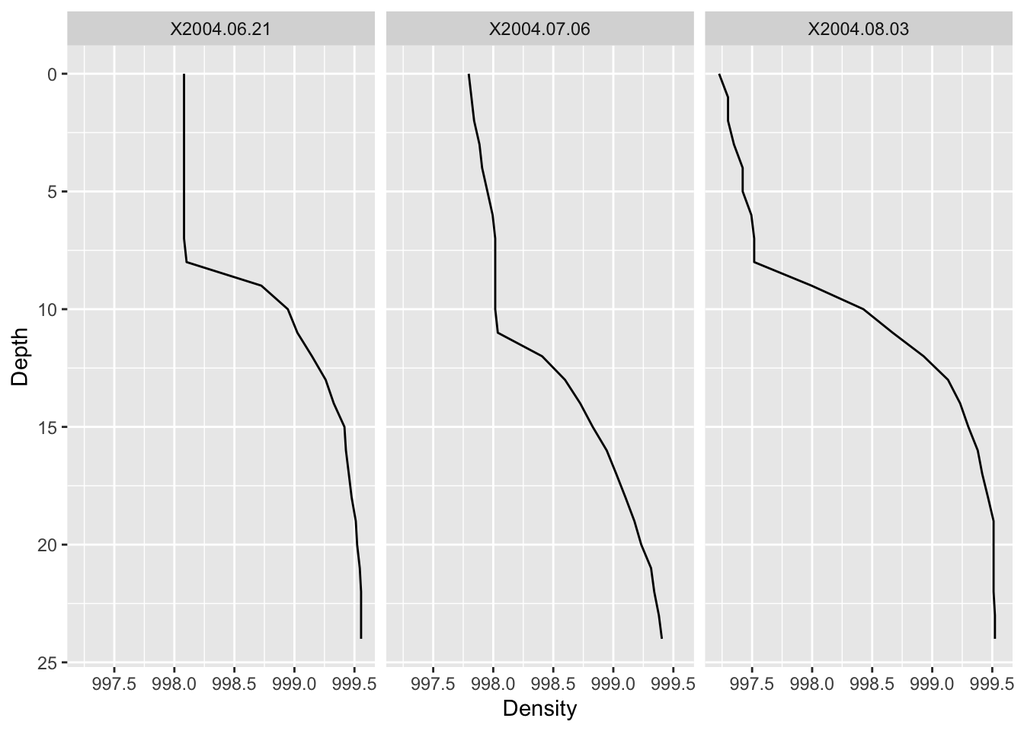

```r
# Density function, where the argument is water temperature in deg C
dens <- function(wtemp) {
  density = 999.842594+6.793952e-2*wtemp-9.09529e-3*wtemp^2+1.001685e-4*wtemp^3-1.120083e-6*wtemp^4+6.536332e-9*wtemp^5
  return(density)
}

# Create a new column in your wtempLong dataframe for water density
wtempLong = wtempLong %>% mutate(Density = dens(Temp))

# Plot density profiles
ggplot(wtempLong) + geom_path(aes(x = Density, y = Depth)) +
  scale_y_reverse() +
  facet_grid(cols = vars(Date))
```

## (2) Calculate buoyancy frequencies

$$N = \sqrt{ \frac{g}{\rho} \frac{d\rho}{dz}}$$

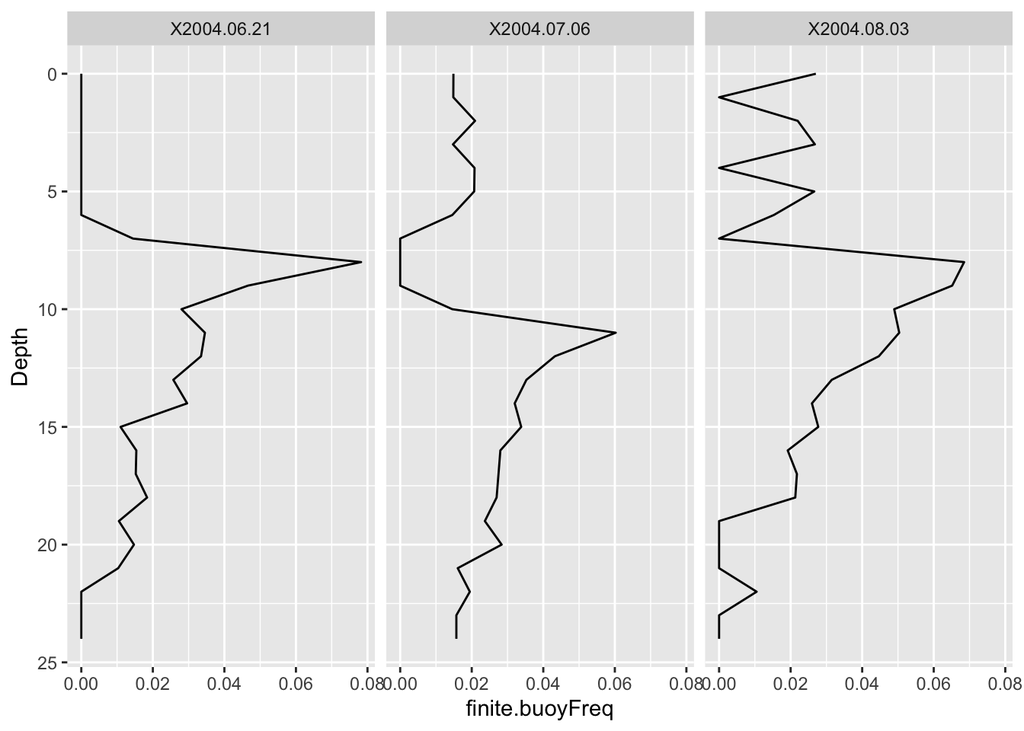

```r
# RECOMMENDED: Create a column in your dataframe for the difference in density
wtempLong = wtempLong %>% mutate(dp = Density - lag(Density)) %>%
  mutate(dp = ifelse(Depth == 0, NA, dp)) #Because we have different dates together, anywhere depth is zero, we want to change that value to NA

# ALTERNATIVELY, approximate all derivations by using forward and backward differencing (finite differences)
# forward differencing: dp/dz = f'(z) = (f(z+h) - f(z)) / h
# backward differencing: f'(z) = (f(z) - f(z-h)) / h
# also, there is central differencing: f'(z) = (f(z+h) - f(z-h)) / 2h
wtempLong = wtempLong %>% mutate(finite.dp = lead(Density) - Density) %>%
  mutate(finite.dp = ifelse(Depth == max(Depth), Density - lag(Density), finite.dp)) #Because we have different dates together, anywhere depth is zero, we want to change that value to NA

# Create a column for buoyancy frequency. In this case our dz is always 1
wtempLong = wtempLong %>% mutate(buoyFreq = sqrt(9.81/998.2 * (dp/1))) %>%
  mutate(finite.buoyFreq = sqrt(9.81/998.2 * (finite.dp/1)))

# Plot Buoyancy Frequency
ggplot(wtempLong) + geom_path(aes(x = finite.buoyFreq, y = Depth)) +
  scale_y_reverse() +
  facet_grid(cols = vars(Date))
```

```r
# Find the max depth
maxDepths = wtempLong %>% group_by(Date) %>%
    filter(finite.buoyFreq == max(finite.buoyFreq,na.rm = T))

paste('Maximum buoyancy frequencies on',maxDepths$Date,' are at depths of:',round(maxDepths$Depth,2), 'm')
```

```
## [1] "Maximum buoyancy frequencies on X2004.06.21  are at depths of: 8 m"
## [2] "Maximum buoyancy frequencies on X2004.07.06  are at depths of: 11 m"
## [3] "Maximum buoyancy frequencies on X2004.08.03  are at depths of: 8 m"
```

## (3) Which velocity will cause a turbulent regime?

$$R_i = \frac{N^2}{\frac{du}{dz}^2}$$
$$0.25 >> \frac{N^2}{\frac{du}{dz}^2}$$
$$\frac{du}{dz}^2 >> 4 * N^2$$
$${\Delta u} >> \sqrt{4 * N^2}$$
When the Richardson number is less than 0.25, internal waves spontaneously appear, and break.

```r
# Find the wind speed required for a Richardson number < 0.25

windSpeeds = wtempLong %>% group_by(Date) %>%
    filter(buoyFreq == max(finite.buoyFreq,na.rm = T)) %>%
    mutate(windSpeed = sqrt(4*buoyFreq))

paste('Critical velocities for turbulence on',windSpeeds$Date,' are:',round(windSpeeds$windSpeed,2), 'm/s')
```

```
## [1] "Critical velocities for turbulence on X2004.06.21  are: 0.56 m/s"
## [2] "Critical velocities for turbulence on X2004.07.06  are: 0.49 m/s"
## [3] "Critical velocities for turbulence on X2004.08.03  are: 0.52 m/s"
```

## (4) Calculate the Schmidt stability

$$z_g = \frac{1}{V} \sum{A_z *z}$$
$$S_t= \frac{g}{A_0} \sum{(z_g - z) * A_z * (p_i - \rho_z)}$$

g = acceleration due to gravity Ao = surface area of the lake zg = the volume centroid (vertical position of the centre of lake volume) z = depth Az = the area of at depth z pi = initial uniform density (we’re going to set this at 1000) pz = observed density at depth z

```r
hypso = hypso %>% mutate(Az = Depth*Area)

# The volume centroid
zg <- 1/V * sum(hypso$Az)
pi = 1000

ss.df = wtempLong %>% left_join(hypso, by = 'Depth')
# Add new row for $$ sum{(z_g - z) * A_z * (p_i - \rho_z)}$$
ss.df = ss.df %>% mutate(s = (zg - Depth) * Area * (1000 - Density))

schmidtStability = ss.df %>% group_by(Date) %>%
    summarise(s = sum(s,na.rm = T)) %>%
    mutate(schmidtStability =  9.81/hypso[1,2] * s)

paste('Schmidt stability on',windSpeeds$Date,' are:',round(schmidtStability$schmidtStability,1))
```

```
## [1] "Schmidt stability on X2004.06.21  are: 521"
## [2] "Schmidt stability on X2004.07.06  are: 462.6"
## [3] "Schmidt stability on X2004.08.03  are: 766.1"
```